# Applied Statistics: Lab 2

Yangzom Dolma

2021-02-05

# Task 1

```r
getwd()
```

```
## [1] "/Users/yangzomdolma/Desktop/StatsYang0019/Labs/Lab2"
```

# Task 2

```r
epagas = read.csv("EPAGAS.csv")
head(epagas)
```

```
##    MPG
## 1 36.3
## 2 41.0
## 3 36.9
## 4 37.1
## 5 44.9
## 6 36.8
```

# Task 3

Make the object mpg, the number of miles per gallon vector.

```r
mpg <- epagas$MPG
head(mpg)
```

```
## [1] 36.3 41.0 36.9 37.1 44.9 36.8
```

z-score of MPG:

```r
z = (mpg - mean(mpg))/sd(mpg)
head(z)
```

```
## [1] -0.28702628  1.65681163 -0.03887676  0.04383975  3.26978352 -0.08023501
```

Verifying that mean(z) = 0 and that standard deviation of z is 1.

```r
round(mean(z))
```

```
## [1] 0
```

```r
sd(z)
```

```
## [1] 1
```

Possible outliers for the values of mpg:

```r
poutliers = mpg[abs(z) >= 2 & abs(z) <= 3]
poutliers
```

```
## [1] 30.0 42.1 31.8
```

The values of mpg that are outliers:

```r
outlier = mpg[abs(z) > 3]
outlier
```

```
## [1] 44.9
```

Dotplot using lattice package:

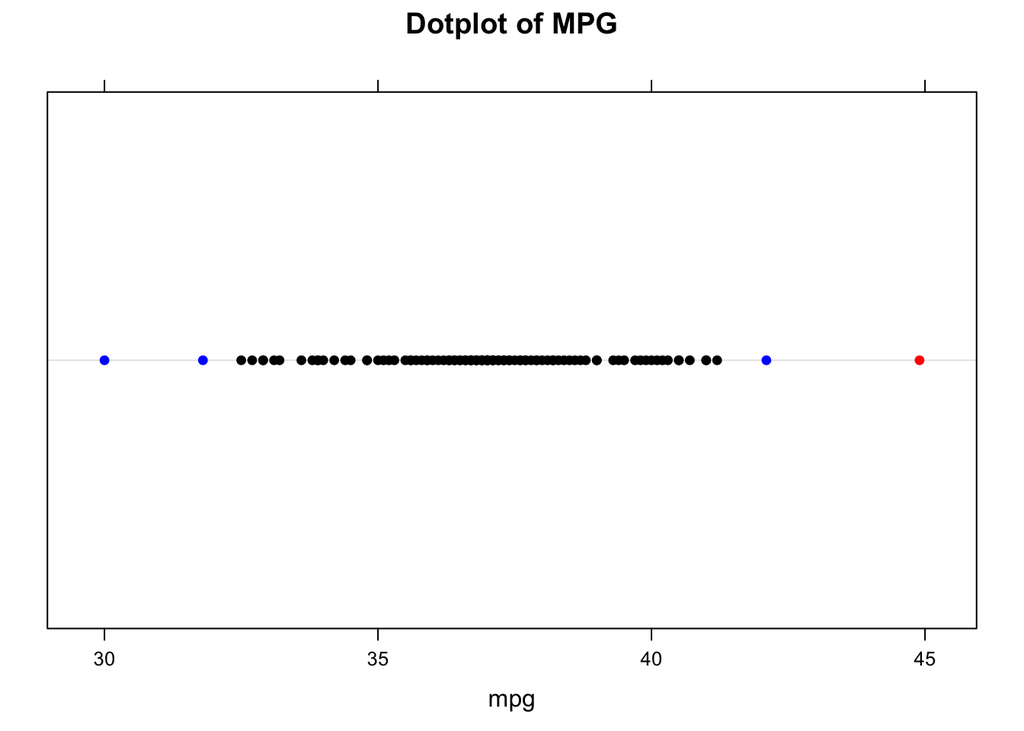

```r
library(lattice)
mpgplot = ifelse(abs(z) > 3, "red",
                 ifelse(abs(z) >=2 & abs(z) <= 3, "blue", "black"))
dotplot(mpg, col = mpgplot, main = "Dotplot of MPG")
```

# Task 4

Boxplot of MPG data:

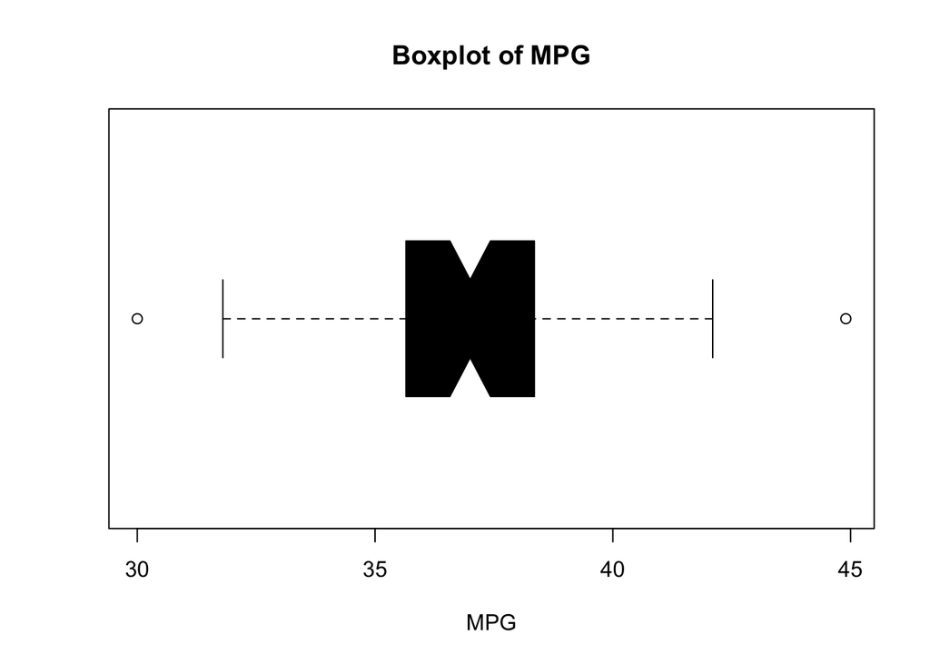

```r
boxplot(mpg,
        main = "Boxplot of MPG",
        col = "black",
        xlab = "MPG",
        horizontal = TRUE,
        notch = TRUE)
```

### Chebyshev’s Theorem

Using Chebyshev’s Theorem: Proportion of MPG data within 2 standard deviations of the mean.

```r
k = 2
ch = (1 - 1/k^2)
ch
```

```
## [1] 0.75
```

Using R: Proportion of MPG data within 2 standard deviations of the mean.

```r
twoSD = mpg[abs(z) < 2]
exact = length(twoSD)/length(mpg)
exact
```

```
## [1] 0.96
```

Does Chebyshev agree with the data?

Ans: Yes, Chebyshev agree with the data. Chebyshev indicates that at least 75% of the MPG data will be within 2 standard deviations of the mean. The exact proportion of data within 2 standard deviations of the mean is found to be 96% which is more than 75%.

### Empirical Rule

According to the empirical rule, approximately 95% of the data should be within 2 standard deviations of the mean of the data.

In this case, we found that 96% of the data is within 2 standard deviations of the mean, which correspond approximately close to 95%.

Density Distribution Plot of MPG data:

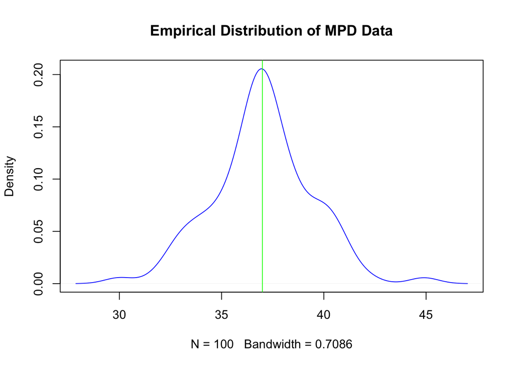

```r
plot(density(mpg), main = "Empirical Distribution of MPD Data", col = "blue")
abline (v = mean(mpg), col = "green")
```

The density distribution plot of MPG data is mound-shaped and has symmetric distribution. Therefore,in this case the empirical rule is valid.